# Проект: "Стримчик" смотрит в будущее

#### Анализ для каждой платформы

Напомним, что у нас 11 актуальных платформ в `actual_platfotms` мы храним их порядке уменьшения общих продаж. Вы можете смотреть не все 11, а ровно столько сколько хотите. Для выбора измените параметр `m` в ячейке ниже.

А для удобства работы вы можете еще для каждой из рассматриваемых платформ посмотреть ТОП-`n` игр по общим продажам. Для этого нужно, так же, в ячейке ниже поменять `n`.

По умолчанию мы посмотрим ТОП-5 платформ. Дополнительно, найдем для них ТОП-5 игр.

```python
# ТОП-n игр по платформам
n = 5
# ТОП-m платформ
m = 5
```

```
'Статистика для платформы 3DS по продажам игр (млн)'
```

```
count    303.000000
mean       0.472772
std        1.381347
min        0.010000
25%        0.040000
50%        0.090000
75%        0.280000
max       14.600000
Name: total_sales, dtype: float64
```

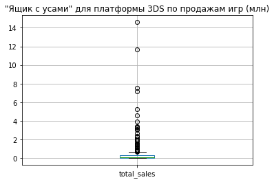

```
'Корреляция на платформе 3DS '
```

|  | year_of_release | na_sales | eu_sales | jp_sales | other_sales | critic_score | user_score | total_sales |
| --- | --- | --- | --- | --- | --- | --- | --- | --- |
| year_of_release | 1.000000 | -0.075933 | -0.115177 | -0.063487 | -0.083695 | 0.166254 | 0.240047 | -0.090086 |
| na_sales | -0.075933 | 1.000000 | 0.931893 | 0.641878 | 0.993708 | 0.369653 | 0.241036 | 0.938867 |
| eu_sales | -0.115177 | 0.931893 | 1.000000 | 0.633982 | 0.958274 | 0.268851 | 0.114930 | 0.927821 |
| jp_sales | -0.063487 | 0.641878 | 0.633982 | 1.000000 | 0.645306 | 0.301810 | 0.259370 | 0.854173 |
| other_sales | -0.083695 | 0.993708 | 0.958274 | 0.645306 | 1.000000 | 0.354365 | 0.209418 | 0.945649 |
| critic_score | 0.166254 | 0.369653 | 0.268851 | 0.301810 | 0.354365 | 1.000000 | 0.769536 | 0.357057 |
| user_score | 0.240047 | 0.241036 | 0.114930 | 0.259370 | 0.209418 | 0.769536 | 1.000000 | 0.241504 |
| total_sales | -0.090086 | 0.938867 | 0.927821 | 0.854173 | 0.945649 | 0.357057 | 0.241504 | 1.000000 |

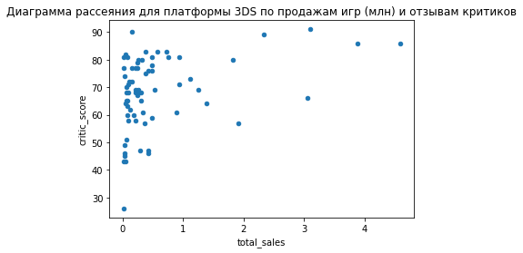

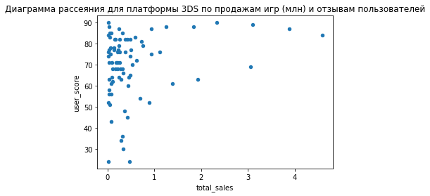

```
'ТОП-5 игр для платформы 3DS:'
```

|  | name | platform | year_of_release | genre | na_sales | eu_sales | jp_sales | other_sales | critic_score | user_score | rating | total_sales |
| --- | --- | --- | --- | --- | --- | --- | --- | --- | --- | --- | --- | --- |
| 0 | pokemon x pokemon y | 3DS | 2013 | Role-Playing | 5.28 | 4.19 | 4.35 | 0.78 | <NA> | <NA> | noESRB | 14.60 |
| 1 | pokemon omega ruby pokemon alpha sapphire | 3DS | 2014 | Role-Playing | 4.35 | 3.49 | 3.10 | 0.74 | <NA> | <NA> | noESRB | 11.68 |
| 2 | super smash bros for wii u and 3ds | 3DS | 2014 | Fighting | 3.27 | 1.37 | 2.43 | 0.48 | <NA> | <NA> | noESRB | 7.55 |
| 3 | pokemon sun moon | 3DS | 2016 | Role-Playing | 2.98 | 1.45 | 2.26 | 0.45 | <NA> | <NA> | noESRB | 7.14 |
| 4 | tomodachi life | 3DS | 2013 | Simulation | 0.97 | 2.11 | 1.90 | 0.24 | <NA> | <NA> | noESRB | 5.22 |

```
'Статистика для платформы PS3 по продажам игр (млн)'
```

```
count    345.000000
mean       0.525884
std        1.451939
min        0.010000
25%        0.040000
50%        0.150000
75%        0.510000
max       21.050000
Name: total_sales, dtype: float64
```

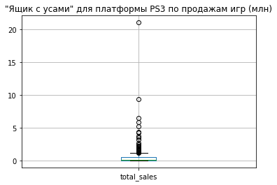

```
'Корреляция на платформе PS3 '
```

|  | year_of_release | na_sales | eu_sales | jp_sales | other_sales | critic_score | user_score | total_sales |
| --- | --- | --- | --- | --- | --- | --- | --- | --- |
| year_of_release | 1.000000 | -0.217596 | -0.167604 | -0.195894 | -0.181897 | -0.167495 | -0.270341 | -0.201274 |
| na_sales | -0.217596 | 1.000000 | 0.874896 | 0.439867 | 0.932098 | 0.335205 | -0.013560 | 0.954921 |
| eu_sales | -0.167604 | 0.874896 | 1.000000 | 0.443809 | 0.975743 | 0.309561 | -0.022848 | 0.974740 |
| jp_sales | -0.195894 | 0.439867 | 0.443809 | 1.000000 | 0.459609 | 0.302327 | 0.244048 | 0.516258 |
| other_sales | -0.181897 | 0.932098 | 0.975743 | 0.459609 | 1.000000 | 0.315748 | 0.004633 | 0.989812 |
| critic_score | -0.167495 | 0.335205 | 0.309561 | 0.302327 | 0.315748 | 1.000000 | 0.599920 | 0.334285 |
| user_score | -0.270341 | -0.013560 | -0.022848 | 0.244048 | 0.004633 | 0.599920 | 1.000000 | 0.002394 |
| total_sales | -0.201274 | 0.954921 | 0.974740 | 0.516258 | 0.989812 | 0.334285 | 0.002394 | 1.000000 |

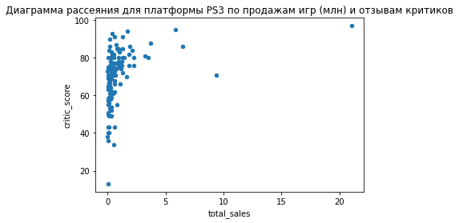

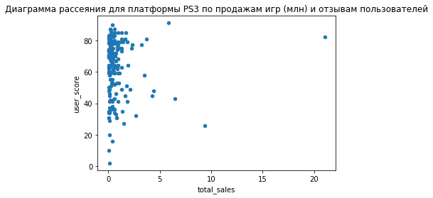

```
'ТОП-5 игр для платформы PS3:'
```

|  | name | platform | year_of_release | genre | na_sales | eu_sales | jp_sales | other_sales | critic_score | user_score | rating | total_sales |
| --- | --- | --- | --- | --- | --- | --- | --- | --- | --- | --- | --- | --- |
| 0 | grand theft auto v | PS3 | 2013 | Action | 7.02 | 9.09 | 0.98 | 3.96 | 97 | 82 | M | 21.05 |
| 1 | call of duty ghosts | PS3 | 2013 | Shooter | 4.10 | 3.63 | 0.38 | 1.25 | 71 | 26 | M | 9.36 |
| 2 | fifa 14 | PS3 | 2013 | Sports | 0.78 | 4.24 | 0.07 | 1.37 | 86 | 43 | E | 6.46 |
| 3 | the last of us | PS3 | 2013 | Action | 2.41 | 2.18 | 0.28 | 0.99 | 95 | 91 | M | 5.86 |
| 4 | minecraft | PS3 | 2014 | Misc | 2.03 | 2.37 | 0.00 | 0.87 | <NA> | <NA> | noESRB | 5.27 |

```
'Статистика для платформы PS4 по продажам игр (млн)'
```

```
count    392.000000
mean       0.801378
std        1.609456
min        0.010000
25%        0.060000
50%        0.200000
75%        0.730000
max       14.630000
Name: total_sales, dtype: float64
```

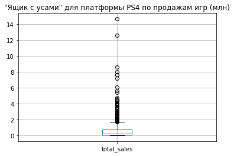

```
'Корреляция на платформе PS4 '
```

|  | year_of_release | na_sales | eu_sales | jp_sales | other_sales | critic_score | user_score | total_sales |
| --- | --- | --- | --- | --- | --- | --- | --- | --- |
| year_of_release | 1.000000 | -0.248551 | -0.208201 | -0.061473 | -0.234608 | -0.021142 | 0.152447 | -0.234822 |
| na_sales | -0.248551 | 1.000000 | 0.785362 | 0.472981 | 0.944259 | 0.415008 | -0.020933 | 0.928160 |
| eu_sales | -0.208201 | 0.785362 | 1.000000 | 0.464563 | 0.944698 | 0.346720 | -0.048925 | 0.958157 |
| jp_sales | -0.061473 | 0.472981 | 0.464563 | 1.000000 | 0.496467 | 0.322358 | 0.171332 | 0.527129 |
| other_sales | -0.234608 | 0.944259 | 0.944698 | 0.496467 | 1.000000 | 0.409191 | -0.035639 | 0.998051 |
| critic_score | -0.021142 | 0.415008 | 0.346720 | 0.322358 | 0.409191 | 1.000000 | 0.557654 | 0.406568 |
| user_score | 0.152447 | -0.020933 | -0.048925 | 0.171332 | -0.035639 | 0.557654 | 1.000000 | -0.031957 |
| total_sales | -0.234822 | 0.928160 | 0.958157 | 0.527129 | 0.998051 | 0.406568 | -0.031957 | 1.000000 |

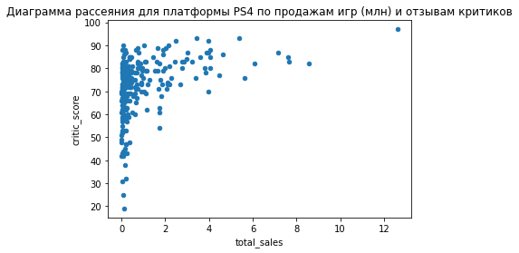

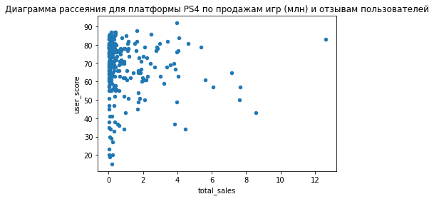

```
'ТОП-5 игр для платформы PS4:'
```

|  | name | platform | year_of_release | genre | na_sales | eu_sales | jp_sales | other_sales | critic_score | user_score | rating | total_sales |
| --- | --- | --- | --- | --- | --- | --- | --- | --- | --- | --- | --- | --- |
| 0 | call of duty black ops 3 | PS4 | 2015 | Shooter | 6.03 | 5.86 | 0.36 | 2.38 | <NA> | <NA> | noESRB | 14.63 |
| 1 | grand theft auto v | PS4 | 2014 | Action | 3.96 | 6.31 | 0.38 | 1.97 | 97 | 83 | M | 12.62 |
| 2 | fifa 16 | PS4 | 2015 | Sports | 1.12 | 6.12 | 0.06 | 1.28 | 82 | 43 | E | 8.58 |
| 3 | star wars battlefront 2015 | PS4 | 2015 | Shooter | 2.99 | 3.49 | 0.22 | 1.28 | <NA> | <NA> | noESRB | 7.98 |
| 4 | call of duty advanced warfare | PS4 | 2014 | Shooter | 2.81 | 3.48 | 0.14 | 1.23 | 83 | 57 | M | 7.66 |

```
'Статистика для платформы X360 по продажам игр (млн)'
```

```
count    186.000000
mean       0.735484
std        1.663275
min        0.010000
25%        0.080000
50%        0.265000
75%        0.795000
max       16.270000
Name: total_sales, dtype: float64
```

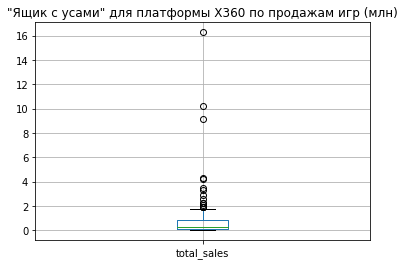

```
'Корреляция на платформе X360 '
```

|  | year_of_release | na_sales | eu_sales | jp_sales | other_sales | critic_score | user_score | total_sales |
| --- | --- | --- | --- | --- | --- | --- | --- | --- |
| year_of_release | 1.000000 | -0.218293 | -0.203537 | -0.285360 | -0.218199 | -0.245439 | -0.248736 | -0.220495 |
| na_sales | -0.218293 | 1.000000 | 0.866574 | 0.634340 | 0.985236 | 0.342724 | -0.012298 | 0.984299 |
| eu_sales | -0.203537 | 0.866574 | 1.000000 | 0.612002 | 0.934769 | 0.336418 | -0.009435 | 0.941008 |
| jp_sales | -0.285360 | 0.634340 | 0.612002 | 1.000000 | 0.641529 | 0.290613 | 0.112592 | 0.648860 |
| other_sales | -0.218199 | 0.985236 | 0.934769 | 0.641529 | 1.000000 | 0.349204 | -0.018868 | 0.998640 |
| critic_score | -0.245439 | 0.342724 | 0.336418 | 0.290613 | 0.349204 | 1.000000 | 0.520946 | 0.350345 |
| user_score | -0.248736 | -0.012298 | -0.009435 | 0.112592 | -0.018868 | 0.520946 | 1.000000 | -0.011742 |
| total_sales | -0.220495 | 0.984299 | 0.941008 | 0.648860 | 0.998640 | 0.350345 | -0.011742 | 1.000000 |

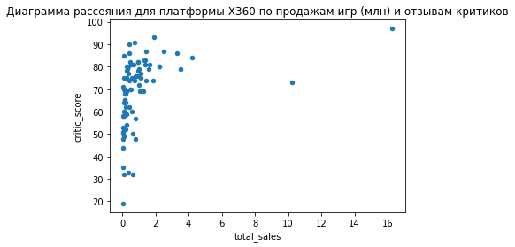

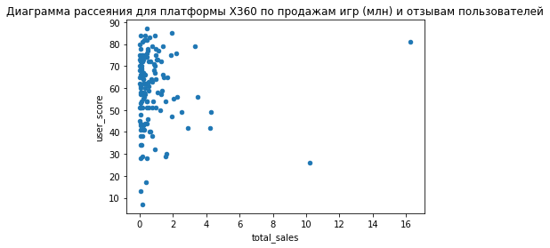

```
'ТОП-5 игр для платформы X360:'
```

|  | name | platform | year_of_release | genre | na_sales | eu_sales | jp_sales | other_sales | critic_score | user_score | rating | total_sales |
| --- | --- | --- | --- | --- | --- | --- | --- | --- | --- | --- | --- | --- |
| 0 | grand theft auto v | X360 | 2013 | Action | 9.66 | 5.14 | 0.06 | 1.41 | 97 | 81 | M | 16.27 |
| 1 | call of duty ghosts | X360 | 2013 | Shooter | 6.73 | 2.56 | 0.04 | 0.91 | 73 | 26 | M | 10.24 |
| 2 | minecraft | X360 | 2013 | Misc | 5.70 | 2.65 | 0.02 | 0.81 | <NA> | <NA> | noESRB | 9.18 |
| 3 | call of duty advanced warfare | X360 | 2014 | Shooter | 2.77 | 1.11 | 0.00 | 0.40 | <NA> | 49 | M | 4.28 |
| 4 | fifa 14 | X360 | 2013 | Sports | 0.92 | 2.89 | 0.01 | 0.40 | 84 | 42 | E | 4.22 |

```
'Статистика для платформы XOne по продажам игр (млн)'
```

```
count    247.000000
mean       0.645020
std        1.036139
min        0.010000
25%        0.060000
50%        0.220000
75%        0.685000
max        7.390000
Name: total_sales, dtype: float64
```

[3 more figures not shown]

```
'ТОП-5 игр для платформы XOne:'
```

|  | name | platform | year_of_release | genre | na_sales | eu_sales | jp_sales | other_sales | critic_score | user_score | rating | total_sales |
| --- | --- | --- | --- | --- | --- | --- | --- | --- | --- | --- | --- | --- |
| 0 | call of duty black ops 3 | XOne | 2015 | Shooter | 4.59 | 2.11 | 0.01 | 0.68 | <NA> | <NA> | noESRB | 7.39 |
| 1 | grand theft auto v | XOne | 2014 | Action | 2.81 | 2.19 | 0.00 | 0.47 | 97 | 79 | M | 5.47 |
| 2 | call of duty advanced warfare | XOne | 2014 | Shooter | 3.22 | 1.55 | 0.01 | 0.48 | 81 | 54 | M | 5.26 |
| 3 | halo 5 guardians | XOne | 2015 | Shooter | 2.78 | 1.27 | 0.03 | 0.41 | 84 | 64 | T | 4.49 |
| 4 | fallout 4 | XOne | 2015 | Role-Playing | 2.51 | 1.32 | 0.01 | 0.38 | 88 | 62 | M | 4.22 |

```python
# Запускаем переборку данных по платформам
for column_name, column_slice in data.groupby('platform'):
    # проверим, что входит в ТОП-m платформ
    if (actual_platforms[0: m].isin([column_name]).sum() == 1):
        # Посчитаем статистику
        display(f'Статистика для платформы {column_name} по продажам игр (млн)')
        display(column_slice['total_sales'].describe())
        # Нарисуем boxplot
        column_slice.boxplot(column=['total_sales'])
        plt.title(f'"Ящик с усами" для платформы {column_name} по продажам игр (млн)')
        plt.show()
        display(f'Корреляция на платформе {column_name} ', column_slice.corr())
        # график рассеивания для продаж и оценок критиков
        column_slice.plot.scatter(x='total_sales'
                                  , y='critic_score'
        )
        plt.ylim=(0, 100)
        plt.title(f'Диаграмма рассеяния для платформы {column_name} по продажам игр (млн) и отзывам критиков')
        plt.show()
        # график рассеивания для продаж и оценок пользователей
        column_slice.plot.scatter(x='total_sales'
                                  , y='user_score'
        )
        plt.ylim=(0, 100)
        plt.title(f'Диаграмма рассеяния для платформы {column_name} по продажам игр (млн) и отзывам пользователей')
        plt.show()
        # Отобразим ТОП-5 игр для каждой платформы
        display(f'ТОП-{n} игр для платформы {column_name}:')
        display( column_slice.sort_values(by='total_sales', ascending=False, ignore_index=True).head(n))
```

#### Общая картина: Продажи на платформах в актальный период

Данные для каждой платформы - это замечетально, но, чтобы увидеть общую картину, соберем данные в общие таблицы и графики.

Нарисуем график и выведем данные по продажам на платформах без разделения на года выпущенных игр.

|  | platform | all_sales |
| --- | --- | --- |
| 0 | PS4 | 314.14 |
| 1 | PS3 | 181.43 |
| 2 | XOne | 159.32 |
| 3 | 3DS | 143.25 |
| 4 | X360 | 136.80 |
| 5 | WiiU | 64.63 |
| 6 | PC | 40.06 |
| 7 | PSV | 32.99 |
| 8 | Wii | 13.66 |
| 9 | PSP | 3.74 |
| 10 | DS | 1.54 |

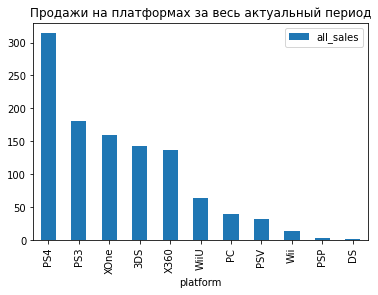

```python
platforms_all_sales[['platform', 'all_sales']].plot(kind='bar',
                                                   x='platform',
                                                   y='all_sales',
                                                   title= 'Продажи на платформах за весь актуальный период')

platforms_all_sales[['platform', 'all_sales']]
```

Отобразим таблицу и график общих продаж по платформам с разбивкой по годам выпущенных игр.

##### Какие платформы лидируют по продажам, растут или падают?

В атуальный период лидируют по продажам c отрывом более чем в 2 раза платформы из ТОП-5 рейтинга выше. Но **мы не можем оценить динамику, так как наши данные аккумулируют данные продаж по годам выпуска игр, а не по годам продаж.**

```python
platforms_all_sales['platform'].head(5)
```

```
0     PS4
1     PS3
2    XOne
3     3DS
4    X360
Name: platform, dtype: object
```

```python
data_pivot_actual_sales = data.pivot_table(index='platform', columns='year_of_release', values='total_sales', aggfunc='sum')
display('Общие продажи по платформам в актуальны период')
data_pivot_actual_sales
```

```
'Общие продажи по платформам в актуальны период'
```

| year_of_release platform | 2013 | 2014 | 2015 | 2016 |
| --- | --- | --- | --- | --- |
| 3DS | 56.57 | 43.76 | 27.78 | 15.14 |
| DS | 1.54 | NaN | NaN | NaN |
| PC | 13.01 | 13.28 | 8.52 | 5.25 |
| PS3 | 113.25 | 47.76 | 16.82 | 3.60 |
| PS4 | 27.39 | 98.60 | 118.90 | 69.25 |
| PSP | 3.38 | 0.24 | 0.12 | NaN |
| PSV | 10.59 | 11.90 | 6.25 | 4.25 |
| Wii | 8.59 | 3.75 | 1.14 | 0.18 |
| WiiU | 21.65 | 22.03 | 16.35 | 4.60 |
| X360 | 88.58 | 34.74 | 11.96 | 1.52 |
| XOne | 19.57 | 53.46 | 60.14 | 26.15 |

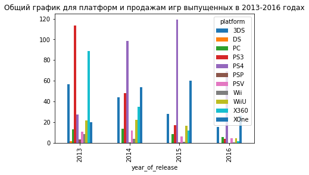

```python
data_pivot_actual_sales.transpose().plot(
    kind='bar'
#    style='o-'
#    , xlim= (2013, 2016)
)
plt.title('Общий график для платформ и продажам игр выпущенных в 2013-2016 годах')
plt.show()
```

##### Выберите несколько потенциально прибыльных платформ.

Мы не можем точно ответить на этот вопрос, так как мы не знаем прибыльность каждой игры и продажи по годам на каждой платформе. Но, скорее всего, потенциально прибыльные платформы, те, на которых продалось больше всего игр в актуальный период. Тоесть ТОП-5. А из этого ТОП-5 мы можем выбрать платформы, где игры последних лет продавались лучше. А это:

- PS4
- XOne
- 3DS

**Выводы**:

#### Общая картина: Ящики с усами

Выше у нас построеные "ящики с усами" для каждой платформы и приведено описание с указанем всех статистических параметров. Но нам нужна общая картина по всем платформам и продажам всех игр на них. Нарисуем её.

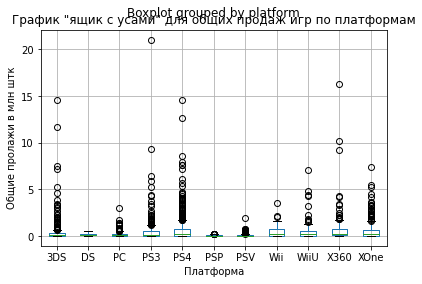

```python
data.boxplot(column='total_sales', by='platform')
plt.title('График "ящик с усами" для общих продаж игр по платформам')
plt.xlabel('Платформа')
plt.ylabel('Общие пролажи в млн штк')
plt.show()
```

Увеличим, чтобы видить квартали, медиану и усы.

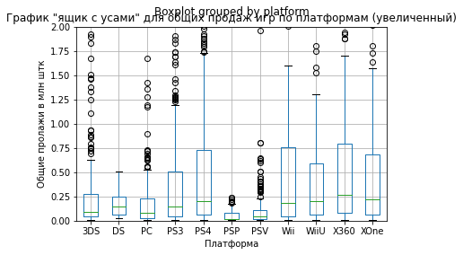

```python
ax = data.boxplot(column='total_sales', by='platform')
ax.set_ylim([0, 2])
plt.title('График "ящик с усами" для общих продаж игр по платформам (увеличенный)')
plt.xlabel('Платформа')
plt.ylabel('Общие пролажи в млн штк')
plt.show()
```

Чтобы численно видеть медианы выведем их таблицой

```python
data_pivot_actual_sales_median = data.pivot_table(index='platform'
#                                                  , columns='year_of_release'
                                                  , values='total_sales'
#                                                  , columns='total_sales'
                                                  , aggfunc=['median'])

data_pivot_actual_sales_median.columns = ['median']
data_pivot_actual_sales_median.sort_values(by='median')

display('Медианы общих продажи игр по платформам в актуальны период')
data_pivot_actual_sales_median
```

```
'Медианы общих продажи игр по платформам в актуальны период'
```

| platform | median |
| --- | --- |
| 3DS | 0.090 |
| DS | 0.150 |
| PC | 0.080 |
| PS3 | 0.150 |
| PS4 | 0.200 |
| PSP | 0.020 |
| PSV | 0.040 |
| Wii | 0.180 |
| WiiU | 0.200 |
| X360 | 0.265 |
| XOne | 0.220 |

**Вывод**:

- как не удивительно, а медианы и квартали, нам подсказывают, что у игр шанс быть проданой выше на платформах: X360, XOne, PS4, WiiU, Wii, PS3, а у 3DS, PC и других меньше... Это важно для магазина, когда покупаешь игры вслепую, например, новые игры (этого или следующего года выпуска)

#### Общая картина: корреляция общих продаж и оценок критиков

Посмотрим на влияние отзывов критиков на продажи.

```python
display('Корреляция общих продаж и оценок критиков по платформам в актуальны период')
data.pivot_table(index='platform', values=['total_sales', 'critic_score'], aggfunc='corr')
```

```
'Корреляция общих продаж и оценок критиков по платформам в актуальны период'
```

| platform |  | critic_score | total_sales |
| --- | --- | --- | --- |
| 3DS | total_sales | 0.357057 | 1.000000 |
|  | critic_score | 1.000000 | 0.357057 |
| DS | total_sales | NaN | 1.000000 |
| PC | total_sales | 0.199660 | 1.000000 |
|  | critic_score | 1.000000 | 0.199660 |
| PS3 | total_sales | 0.334285 | 1.000000 |
|  | critic_score | 1.000000 | 0.334285 |
| PS4 | total_sales | 0.406568 | 1.000000 |
|  | critic_score | 1.000000 | 0.406568 |
| PSP | total_sales | NaN | 1.000000 |
| PSV | total_sales | 0.254742 | 1.000000 |
|  | critic_score | 1.000000 | 0.254742 |
| Wii | total_sales | NaN | 1.000000 |
| WiiU | total_sales | 0.376415 | 1.000000 |
|  | critic_score | 1.000000 | 0.376415 |
| X360 | total_sales | 0.350345 | 1.000000 |
|  | critic_score | 1.000000 | 0.350345 |
| XOne | total_sales | 0.416998 | 1.000000 |
|  | critic_score | 1.000000 | 0.416998 |

Посмотрим на графиках подробнее.

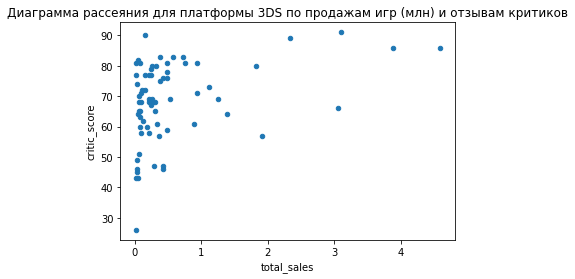

[figure not shown]

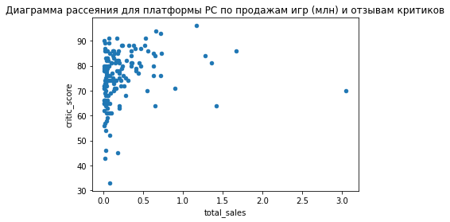

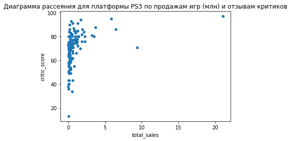

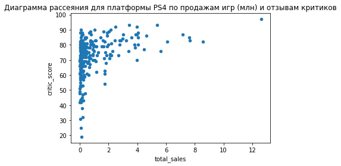

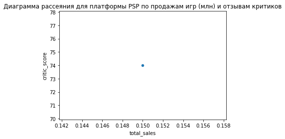

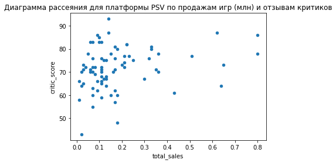

[figure not shown]

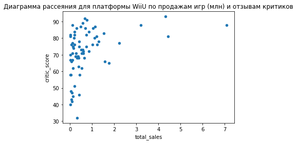

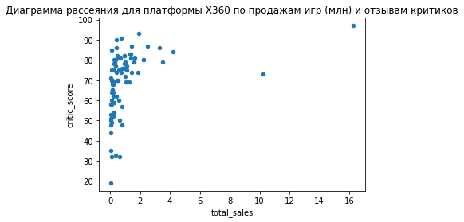

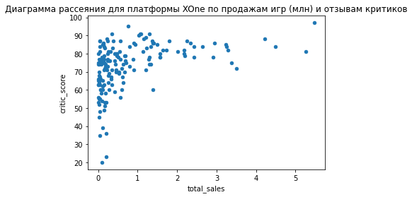

```python
# ТОП-m платформ в актуальном периоде
m = 11
# Запускаем переборку данных по платформам
for column_name, column_slice in data.groupby('platform'):
    # проверим, что входит в ТОП-m платформ
    if (actual_platforms[0: m].isin([column_name]).sum() == 1):
        # график рассеивания для продаж и оценок критиков
        column_slice.plot.scatter(x='total_sales'
                                  , y='critic_score'
        )
        plt.ylim=(0, 100)
        plt.title(f'Диаграмма рассеяния для платформы {column_name} по продажам игр (млн) и отзывам критиков')
        plt.show()
```

#### Общая картина: корреляция общих продаж и оценок пользователей

Посмотрим за зависимость общих продаж от отзывов пользователей.

```python
display('Корреляция общих продаж и оценок пользователей по платформам в актуальны период')
data.pivot_table(index='platform', values=['total_sales', 'user_score'], aggfunc='corr')
```

```
'Корреляция общих продаж и оценок пользователей по платформам в актуальны период'
```

| platform |  | total_sales | user_score |
| --- | --- | --- | --- |
| 3DS | total_sales | 1.000000 | 0.241504 |
|  | user_score | 0.241504 | 1.000000 |
| DS | total_sales | 1.000000 | NaN |
| PC | total_sales | 1.000000 | -0.089998 |
|  | user_score | -0.089998 | 1.000000 |
| PS3 | total_sales | 1.000000 | 0.002394 |
|  | user_score | 0.002394 | 1.000000 |
| PS4 | total_sales | 1.000000 | -0.031957 |
|  | user_score | -0.031957 | 1.000000 |
| PSP | total_sales | 1.000000 | -1.000000 |
|  | user_score | -1.000000 | 1.000000 |
| PSV | total_sales | 1.000000 | 0.000942 |
|  | user_score | 0.000942 | 1.000000 |
| Wii | total_sales | 1.000000 | 0.682942 |
|  | user_score | 0.682942 | 1.000000 |
| WiiU | total_sales | 1.000000 | 0.419330 |
|  | user_score | 0.419330 | 1.000000 |
| X360 | total_sales | 1.000000 | -0.011742 |
|  | user_score | -0.011742 | 1.000000 |
| XOne | total_sales | 1.000000 | -0.068925 |
|  | user_score | -0.068925 | 1.000000 |

Посмотрим подробнее на графиках.

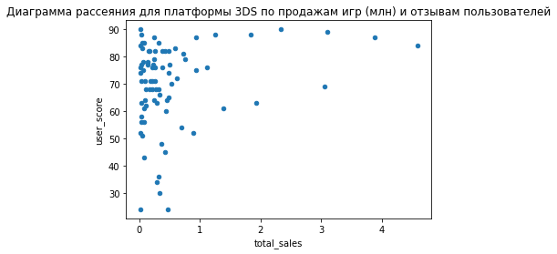

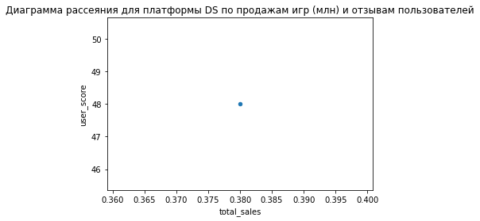

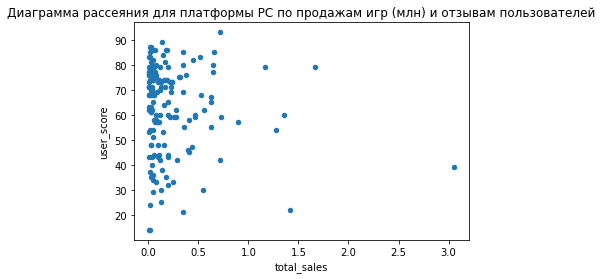

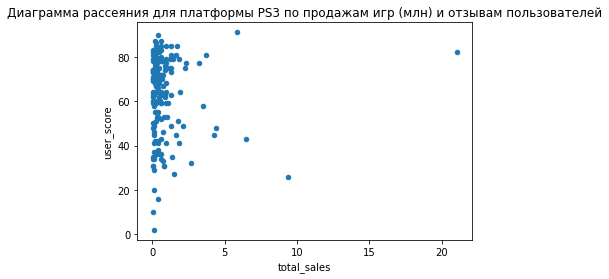

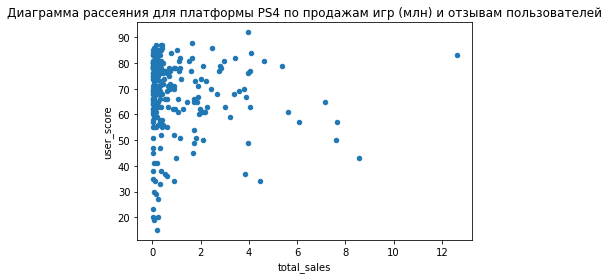

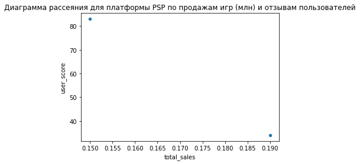

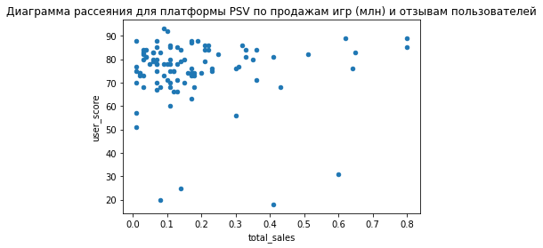

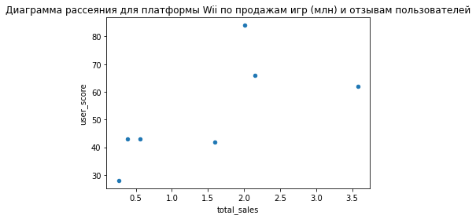

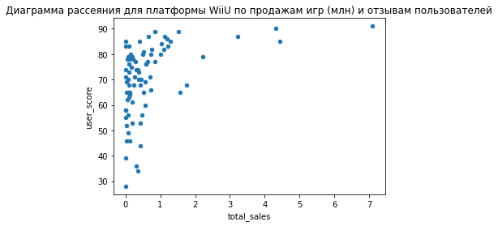

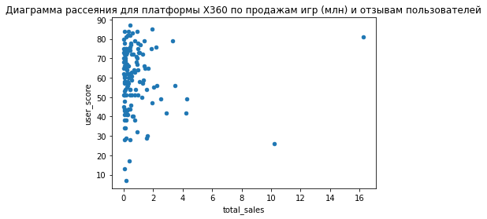

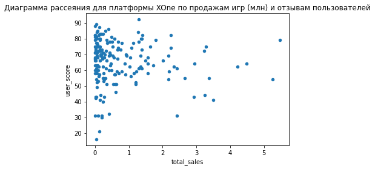

```python
# ТОП-m платформ
m = 11
# Запускаем переборку данных по платформам
for column_name, column_slice in data.groupby('platform'):
    # проверим, что входит в ТОП-m платформ
    if (actual_platforms[0: m].isin([column_name]).sum() == 1):
        column_slice.plot.scatter(x='total_sales'
                                  , y='user_score')
        plt.ylim=(0, 100)
        plt.title(f'Диаграмма рассеяния для платформы {column_name} по продажам игр (млн) и отзывам пользователей')
        plt.show()
```

#### Корреляция для общих продаж на количества игр на платформах

Посчитаем корреляцию для общих продаж на количества игр на платформах. И нарисуем график.

```python
# дадим нужный тип данных
platforms_all_sales['count_names_on_platform'] = pd.to_numeric(platforms_all_sales['count_names_on_platform']
                                                               , downcast='integer')
# корреляция
platforms_all_sales['count_names_on_platform'].corr(platforms_all_sales['all_sales'])
```

```
0.7431261149200807
```

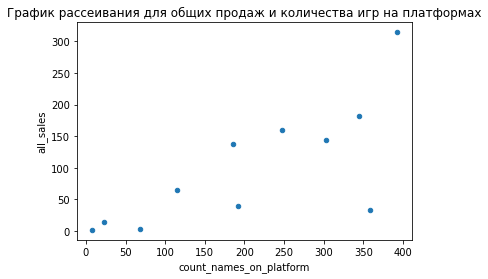

```python
platforms_all_sales.plot.scatter(x='count_names_on_platform', y='all_sales')
plt.title('График рассеивания для общих продаж и количества игр на платформах')
plt.show()
```

```python
# Комментарий ревьюера 2
platforms_all_sales
```

|  | platform | all_sales | count_names_on_platform | na_all_sales | jp_all_sales | eu_all_sales | other_all_sales |
| --- | --- | --- | --- | --- | --- | --- | --- |
| 0 | PS4 | 314.14 | 392 | 108.74 | 15.96 | 141.09 | 48.35 |
| 1 | PS3 | 181.43 | 345 | 63.50 | 23.35 | 67.81 | 26.77 |
| 2 | XOne | 159.32 | 247 | 93.12 | 0.34 | 51.59 | 14.27 |
| 3 | 3DS | 143.25 | 303 | 38.20 | 67.81 | 30.96 | 6.28 |
| 4 | X360 | 136.80 | 186 | 81.66 | 0.51 | 42.52 | 12.11 |
| 5 | WiiU | 64.63 | 115 | 29.21 | 10.88 | 19.85 | 4.69 |
| 6 | PC | 40.06 | 192 | 11.19 | 0.00 | 25.84 | 3.03 |
| 7 | PSV | 32.99 | 358 | 5.04 | 18.59 | 6.10 | 3.26 |
| 8 | Wii | 13.66 | 23 | 6.56 | 0.05 | 5.93 | 1.12 |
| 9 | PSP | 3.74 | 68 | 0.00 | 3.53 | 0.17 | 0.04 |
| 10 | DS | 1.54 | 8 | 0.57 | 0.00 | 0.85 | 0.12 |

**Вывод**: Зависимость сильная.

Один в поле не воин...

#### Выводы

**Выводы**:

По сумме информации:

- PS4 - перспективна, закупаемся на 7 из 10, смотрим отзывы критиков, можно брать новинки
- PS3 - поддерживаем ассортимент, закупаемся на 4 из 10, смотрим отзывы критиков
- XOne - перспективна, закупаемся на 10 из 10, смотрим отзывы критиков, нужно брать новинки
- 3DS - потенциально перспективно, закупаемся на 3 из 10, смотрим отзывы критиков
- X360 - поддерживаем ассортимен(старичек еще крепок), закупемся на 8 из 10, смотрим отзывы критиков
- WiiU - потенциально перспективно, закупаемся на 4 из 10, смотрим отзывы пользователей, можно брать новинки
- PC - поддерживаем ассортимент, закупаемся на 2 из 10 (Европа), смотрим отзывы критиков

И на первый взгляд все мы любим пострелять и покататься на новых платформах. Разберемся в последнем пункте поподробнее...

### Жанры на актуальных данных крупными мазками

Какие у нас жанры?

```python
display('У нас есть игры следующих жанров')
data['genre'].unique()
```

```
'У нас есть игры следующих жанров'
```

```
array(['Action', 'Shooter', 'Role-Playing', 'Misc', 'Sports', 'Fighting',
       'Racing', 'Simulation', 'Platform', 'Strategy', 'Adventure',
       'Puzzle'], dtype=object)
```

Сколько их?

```python
display ('Количество жанров', len(data['genre'].unique()) )
```

```
'Количество жанров'
```

```
12
```

Сколько игр в каждом из жанров? Сделаем табличку и нарисуем.

```python
display('В каждом жанре такое количество игр')
data['genre'].value_counts()
```

```
'В каждом жанре такое количество игр'
```

```
Action          769
Role-Playing    292
Adventure       245
Sports          214
Shooter         187
Misc            156
Racing           85
Fighting         80
Platform         74
Simulation       62
Strategy         56
Puzzle           17
Name: genre, dtype: int64
```

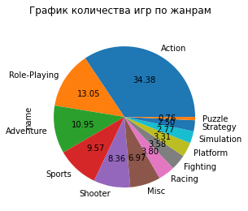

```python
(data.pivot_table(index='genre', values='name', aggfunc='count')
 .sort_values(by='name', ascending=False)
 .plot(kind='pie', sharey=True, subplots=True, title='График количества игр по жанрам'
       , legend=False, autopct='%.2f')
)
plt.show()
```

Какие у нас общие продажи по жанрам? Сделаем таблицу и нарисуем.

```
'Общие продажи по жанрам'
```

| genre | total_sales |
| --- | --- |
| Action | 322.50 |
| Shooter | 232.98 |
| Sports | 150.65 |
| Role-Playing | 145.89 |
| Misc | 63.06 |
| Platform | 42.63 |
| Racing | 39.89 |
| Fighting | 35.31 |
| Adventure | 23.64 |
| Simulation | 21.76 |
| Strategy | 10.08 |
| Puzzle | 3.17 |

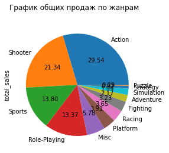

```python
display('Общие продажи по жанрам')
genre_total_sales_sum_pivot_table = data.pivot_table(index='genre', values='total_sales', aggfunc='sum')\
                                        .sort_values(by='total_sales', ascending=False)
display(genre_total_sales_sum_pivot_table)
genre_total_sales_sum_pivot_table.plot(kind='pie', subplots=True, title='График общих продаж по жанрам', legend=False, autopct='%.2f')
plt.show()
```

Соберем данные о Жанрах. Нам нужны количество игр, общие продажи, и медиана для игр. Медиана очень важна, так как не всем быть чемпионами.

```
'Общая таблица количества игр и общих продаж по жанрам'
```

| genre | count total_sales | sum total_sales | median total_sales |
| --- | --- | --- | --- |
| Action | 769 | 322.50 | 0.110 |
| Adventure | 245 | 23.64 | 0.030 |
| Fighting | 80 | 35.31 | 0.125 |
| Misc | 156 | 63.06 | 0.105 |
| Platform | 74 | 42.63 | 0.225 |
| Puzzle | 17 | 3.17 | 0.060 |
| Racing | 85 | 39.89 | 0.120 |
| Role-Playing | 292 | 145.89 | 0.125 |
| Shooter | 187 | 232.98 | 0.450 |
| Simulation | 62 | 21.76 | 0.100 |
| Sports | 214 | 150.65 | 0.240 |
| Strategy | 56 | 10.08 | 0.080 |

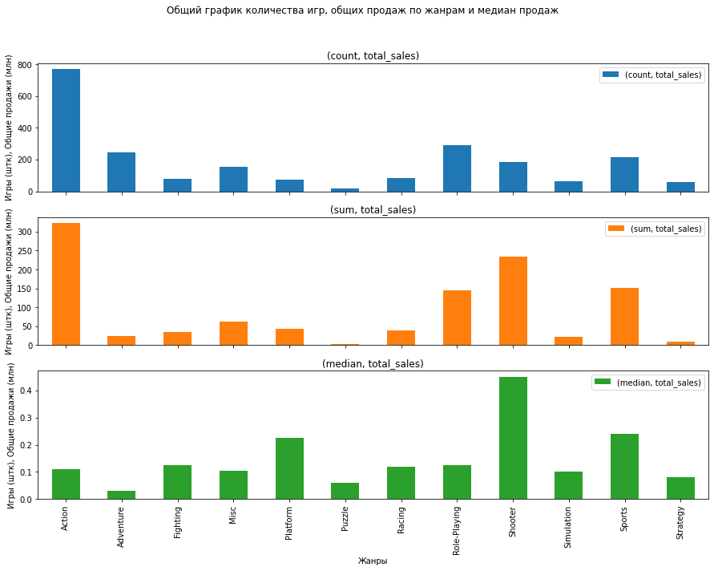

```python
display('Общая таблица количества игр и общих продаж по жанрам')
genre_common_pivot_table = data.pivot_table(index='genre', values='total_sales', aggfunc=['count', 'sum', 'median'])
display(genre_common_pivot_table)
genre_common_pivot_table.plot(kind='bar', xlabel='Жанры', ylabel='Игры (штк), Общие продажи (млн)'
                             , title= 'Общий график количества игр, общих продаж по жанрам и медиан продаж'
                              , figsize = (15, 10)
                              , subplots=True)
plt.show()
```

Предположим, что все игры нам дают одиноковую прибыль на проданную штуку. Проверим, какой жанр дает нам лучшее количество общих продаж на одну игру, и соответственно мы сможем понять для какого жанра потенциально выгоднее писать игры.

```python
# genre_common_pivot_table.info()
genre_common_pivot_table['ratio'] = genre_common_pivot_table['sum']['total_sales'] / genre_common_pivot_table['count']['total_sales']
genre_common_pivot_table.sort_values(by='ratio', ascending=False)
```

| genre | count total_sales | sum total_sales | median total_sales | ratio |
| --- | --- | --- | --- | --- |
| Shooter | 187 | 232.98 | 0.450 | 1.245882 |
| Sports | 214 | 150.65 | 0.240 | 0.703972 |
| Platform | 74 | 42.63 | 0.225 | 0.576081 |
| Role-Playing | 292 | 145.89 | 0.125 | 0.499623 |
| Racing | 85 | 39.89 | 0.120 | 0.469294 |
| Fighting | 80 | 35.31 | 0.125 | 0.441375 |
| Action | 769 | 322.50 | 0.110 | 0.419376 |
| Misc | 156 | 63.06 | 0.105 | 0.404231 |
| Simulation | 62 | 21.76 | 0.100 | 0.350968 |
| Puzzle | 17 | 3.17 | 0.060 | 0.186471 |
| Strategy | 56 | 10.08 | 0.080 | 0.180000 |
| Adventure | 245 | 23.64 | 0.030 | 0.096490 |

Тот же ТОП-3 жанров нам дали медианы. Различия только в местах за 4 и 5 место. Статистика творит чудеса. Хорошо, что мы пришли к одинаковым ТОП-5 жанров.

Посмотрим на график с усами, чтобы лучше понять, что окружает наши медианы.

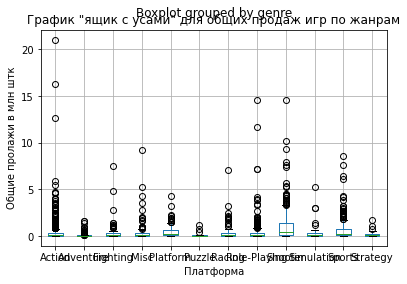

```python
data.boxplot(column='total_sales', by='genre')
plt.title('График "ящик с усами" для общих продаж игр по жанрам')
plt.xlabel('Платформа')
plt.ylabel('Общие пролажи в млн штк')
plt.show()
```

Увеличим, чтобы были виодно медианы, квартали и усы.

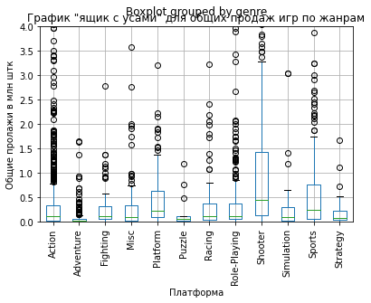

```python
ax = data.boxplot(column='total_sales', by='genre')
ax.set_ylim([0, 4])
plt.title('График "ящик с усами" для общих продаж игр по жанрам')
plt.xlabel('Платформа')
plt.ylabel('Общие пролажи в млн штк')
ax.set_xticklabels(ax.get_xticklabels(),rotation=90)
plt.show()
```

Лучше всего писать стрелялки... Вот бы все войны были только в виртуальном пространстве...

Посмотрим статистику по количеству игр по жанрам.

```python
data['genre'].value_counts().describe()
```

```
count     12.000000
mean     186.416667
std      202.508567
min       17.000000
25%       71.000000
50%      120.500000
75%      221.750000
max      769.000000
Name: genre, dtype: float64
```

Посмотрим статистику по общим продажам по жанрам.

```python
genre_total_sales_sum_pivot_table.describe()
```

|  | total_sales |
| --- | --- |
| count | 12.000000 |
| mean | 90.963333 |
| std | 101.241925 |
| min | 3.170000 |
| 25% | 23.170000 |
| 50% | 41.260000 |
| 75% | 147.080000 |
| max | 322.500000 |

```python
# genre_total_sales_sum_pivot_table.boxplot()
# plt.show()
```

Проверим корреляции наших данных.

```python
genre_common_pivot_table.corr()
```

|  |  | count total_sales | sum total_sales | median total_sales | ratio |
| --- | --- | --- | --- | --- | --- |
| count | total_sales | 1.000000 | 0.841990 | -0.004298 | 0.078414 |
| sum | total_sales | 0.841990 | 1.000000 | 0.502643 | 0.579769 |
| median | total_sales | -0.004298 | 0.502643 | 1.000000 | 0.975745 |
| ratio |  | 0.078414 | 0.579769 | 0.975745 | 1.000000 |

## Портрет пользователя каждого региона

Используем данные подготовленные ранее.

### Северная Америка

#### ТОП-5 платформ по продажам в Северной Америке.

```python
# общий размер рынка
na_total_sales = platforms_all_sales['na_all_sales'].sum()
# display( 'Объем рынка в млн штук', na_total_sales)
# определим доли по платформам
platforms_all_sales['na_market_share'] = platforms_all_sales['na_all_sales'] / na_total_sales
# выведем только запрошенную информацию
# platforms_all_sales.sort_values(by='na_all_sales', ascending=False, ignore_index=True)
(platforms_all_sales
 .sort_values(by='na_all_sales', ascending=False, ignore_index=True)[['platform', 'na_all_sales', 'na_market_share']]
 .head())
```

|  | platform | na_all_sales | na_market_share |
| --- | --- | --- | --- |
| 0 | PS4 | 108.74 | 0.248384 |
| 1 | XOne | 93.12 | 0.212705 |
| 2 | X360 | 81.66 | 0.186528 |
| 3 | PS3 | 63.50 | 0.145047 |
| 4 | 3DS | 38.20 | 0.087256 |

#### ТОП-5 жанров по продажам в Северной Америке

| genre | na_sales | market_share |
| --- | --- | --- |
| Action | 126.13 | 0.288106 |
| Shooter | 109.74 | 0.250668 |
| Sports | 65.27 | 0.149090 |
| Role-Playing | 46.40 | 0.105987 |
| Misc | 27.49 | 0.062793 |

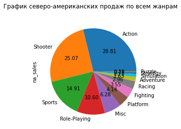

```python
# display('Продажи в Североной Америке по жанрам')
# делаем сводную таблицу по жанрам и продажам
genre_na_sales_sum_pivot_table = data.pivot_table(index='genre', values='na_sales', aggfunc='sum')\
                                        .sort_values(by='na_sales', ascending=False)
# вычисляем доли
genre_na_sales_sum_pivot_table['market_share'] = genre_na_sales_sum_pivot_table['na_sales'] / na_total_sales
display(genre_na_sales_sum_pivot_table.head())
genre_na_sales_sum_pivot_table.plot(kind='pie'
                                    , y= 'na_sales', subplots=True
                                    , title='График северо-американских продаж по всем жанрам'
                                    , autopct='%.2f'

                                    , legend=False)
plt.show()
```

#### ESRB рейтинг, возратные группы и продажи в Северной Америке

По информации сайта www.esrb.org эти категории можно соотнести со следующими возрастными группами (по годам), более привычными в России:

- E - 0+
- E10+ - 10+
- T - 13+
- M - 17+
- RP - рейтинг в ожидании. Иногда добавляется возрастная группа, к чему стремиться ожидание, например, 17+.
- A - 18+

Если мы согласимся с предположениями:

- взрослые (18+) платят за игры,
- взрослые покупают игры для детей, подростков и себе по возрастам,
- количество игр на каждого игрока одинаковое (**это спорное, но важное предположение**),

то продажи по рейтингам ESRB могут показать нам возрастные группы игроков (их доли) в соответствии с возрасными группами, описанными выше.

```
'Продаж в Северной Америке и оценки ESRB в актуальный период'
```

| rating | na_sales | name_quantity | ratio |
| --- | --- | --- | --- |
| E | 79.05 | 302 | 0.180566 |
| E10+ | 54.24 | 252 | 0.123895 |
| M | 165.29 | 372 | 0.377555 |
| T | 49.79 | 333 | 0.113730 |
| noESRB | 89.42 | 978 | 0.204253 |

```
<function matplotlib.pyplot.show(close=None, block=None)>
```

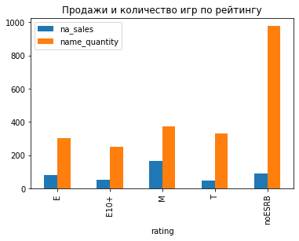

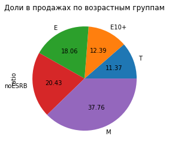

```python
display('Продаж в Северной Америке и оценки ESRB в актуальный период')
# составим таблицу продаж и количества игр по рейтингу
na_sales_rating_pivot = data.pivot_table(index=['rating'], values=['na_sales'], aggfunc=['sum', 'count'])
# поменяем название столбцов
na_sales_rating_pivot.columns = ['na_sales', 'name_quantity']
# посчитаем доли продаж по возрастным группам
na_sales_rating_pivot['ratio'] = na_sales_rating_pivot['na_sales'] / na_total_sales
# выведем таблицу и графики
display (na_sales_rating_pivot)
na_sales_rating_pivot.plot( kind='bar'
                           , y= ['na_sales', 'name_quantity']
                           , title = 'Продажи и количество игр по рейтингу'
)
plt.show
na_sales_rating_pivot.sort_values(by='ratio').plot( kind='pie'
                           , y= 'ratio'
                           , title = 'Доли в продажах по возрастным группам'
                            , autopct='%.2f'
                           , legend=False
)
plt.show
```

### Европа

#### ТОП-5 платформ по продажам в Европе.

```python
# общий размер рынка
eu_total_sales = platforms_all_sales['eu_all_sales'].sum()
# определим доли по платформам
platforms_all_sales['eu_market_share'] = platforms_all_sales['eu_all_sales'] / eu_total_sales
# выведем только запрошенную информацию
# platforms_all_sales.sort_values(by='eu_all_sales', ascending=False, ignore_index=True)
(platforms_all_sales
 .sort_values(by='eu_all_sales', ascending=False, ignore_index=True)[['platform','eu_all_sales', 'eu_market_share']]
 .head())
```

|  | platform | eu_all_sales | eu_market_share |
| --- | --- | --- | --- |
| 0 | PS4 | 141.09 | 0.359273 |
| 1 | PS3 | 67.81 | 0.172672 |
| 2 | XOne | 51.59 | 0.131369 |
| 3 | X360 | 42.52 | 0.108273 |
| 4 | 3DS | 30.96 | 0.078837 |

#### ТОП-5 жанров по продажам в Европе

| genre | eu_sales | market_share |
| --- | --- | --- |
| Action | 118.61 | 0.302029 |
| Shooter | 87.86 | 0.223727 |
| Sports | 60.52 | 0.154109 |
| Role-Playing | 36.97 | 0.094141 |
| Racing | 20.19 | 0.051412 |

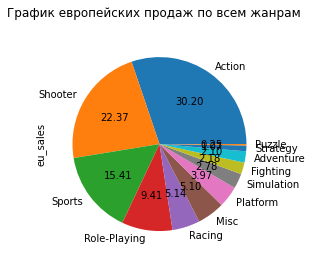

```python
# display('Продажи в Европе по жанрам')
# делаем сводную таблицу по жанрам и продажам
genre_eu_sales_sum_pivot_table = data.pivot_table(index='genre', values='eu_sales', aggfunc='sum')\
                                        .sort_values(by='eu_sales', ascending=False)
# вычисляем доли
genre_eu_sales_sum_pivot_table['market_share'] = genre_eu_sales_sum_pivot_table['eu_sales'] / eu_total_sales
display(genre_eu_sales_sum_pivot_table.head())
genre_eu_sales_sum_pivot_table.plot(kind='pie', y='eu_sales'
                                    , subplots=True
                                    , title='График европейских продаж по всем жанрам'
                                    , autopct='%.2f'
                                    , legend=False)
plt.show()
```

#### ESRB рейтинг, возратные группы и продажи в Европе

По информации сайта www.esrb.org эти категории можно соотнести со следующими возрастными группами (по годам), более привычными в России:

- E - 0+
- E10+ - 10+
- T - 13+
- M - 17+
- RP - рейтинг в ожидании. Иногда добавляется возрастная группа, к чему стремиться ожидание, например, 17+.
- A - 18+

Если мы согласимся с предположениями:

- взрослые (18+) платят за игры,
- взрослые покупают игры для детей, подростков и себе по возрастам,
- количество игр на каждого игрока одинаковое (**это спорное, но важное предположение**),

то продажи по рейтингам ESRB могут показать нам возрастные группы игроков (их доли) в соответствии с возрасными группами, описанными выше.

```
'Продаж в Европе и оценки ESRB в актуальный период'
```

| rating | eu_sales | name_quantity | ratio |
| --- | --- | --- | --- |
| E | 83.36 | 302 | 0.212269 |
| E10+ | 42.69 | 252 | 0.108706 |
| M | 145.80 | 372 | 0.371266 |
| T | 41.95 | 333 | 0.106822 |
| noESRB | 78.91 | 978 | 0.200937 |

```
<function matplotlib.pyplot.show(close=None, block=None)>
```

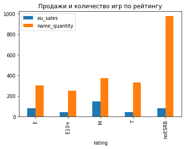

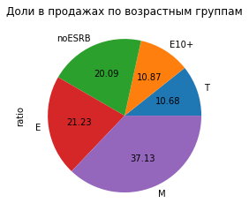

```python
display('Продаж в Европе и оценки ESRB в актуальный период')
# составим таблицу продаж и количества игр по рейтингу
eu_sales_rating_pivot = data.pivot_table(index=['rating'], values=['eu_sales'], aggfunc=['sum', 'count'])
# поменяем название столбцов
eu_sales_rating_pivot.columns = ['eu_sales', 'name_quantity']
# посчитаем доли продаж по возрастным группам
eu_sales_rating_pivot['ratio'] = eu_sales_rating_pivot['eu_sales'] / eu_total_sales
# выведем таблицу и графики
display (eu_sales_rating_pivot)
eu_sales_rating_pivot.plot( kind='bar'
                           , y= ['eu_sales', 'name_quantity']
                           , title = 'Продажи и количество игр по рейтингу'
)
plt.show
eu_sales_rating_pivot.sort_values(by='ratio').plot( kind='pie'
                           , y= 'ratio'
                           , title = 'Доли в продажах по возрастным группам'
                            , autopct='%.2f'
                           , legend=False
)
plt.show
```

### Япония

#### ТОП-5 платформ по продажам в Японии.

```python
# общий размер рынка
jp_total_sales = platforms_all_sales['jp_all_sales'].sum()
# определим доли по платформам
platforms_all_sales['jp_market_share'] = platforms_all_sales['jp_all_sales'] / jp_total_sales
# выведем только запрошенную информацию
# platforms_all_sales.sort_values(by='jp_all_sales', ascending=False, ignore_index=True)
(platforms_all_sales
 .sort_values(by='jp_all_sales', ascending=False, ignore_index=True)[['platform', 'jp_all_sales','jp_market_share']]
 .head())
```

|  | platform | jp_all_sales | jp_market_share |
| --- | --- | --- | --- |
| 0 | 3DS | 67.81 | 0.480854 |
| 1 | PS3 | 23.35 | 0.165579 |
| 2 | PSV | 18.59 | 0.131825 |
| 3 | PS4 | 15.96 | 0.113175 |
| 4 | WiiU | 10.88 | 0.077152 |

#### ТОП-5 жанров по продажам в Японии

| genre | jp_sales | market_share |
| --- | --- | --- |
| Role-Playing | 51.04 | 0.361934 |
| Action | 40.49 | 0.287122 |
| Misc | 9.44 | 0.066941 |
| Fighting | 7.65 | 0.054248 |
| Shooter | 6.61 | 0.046873 |

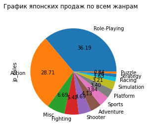

```python
# display('Продажи в Японии по жанрам')
# делаем сводную таблицу по жанрам и продажам
genre_jp_sales_sum_pivot_table = data.pivot_table(index='genre', values='jp_sales', aggfunc='sum')\
                                        .sort_values(by='jp_sales', ascending=False)
# вычисляем доли
genre_jp_sales_sum_pivot_table['market_share'] = genre_jp_sales_sum_pivot_table['jp_sales'] / jp_total_sales
display(genre_jp_sales_sum_pivot_table.head())
genre_jp_sales_sum_pivot_table.plot(kind='pie', y= 'jp_sales'
                                    , subplots=True
                                    , title='График японских продаж по всем жанрам'
                                    , autopct='%.2f'
                                    , legend=False)
plt.show()
```

#### ESRB рейтинг, возратные группы и продажи в Японии

По информации сайта www.esrb.org эти категории можно соотнести со следующими возрастными группами (по годам), более привычными в России:

- E - 0+
- E10+ - 10+
- T - 13+
- M - 17+
- RP - рейтинг в ожидании. Иногда добавляется возрастная группа, к чему стремиться ожидание, например, 17+.
- A - 18+

Если мы согласимся с предположениями:

- взрослые (18+) платят за игры,
- взрослые покупают игры для детей, подростков и себе по возрастам,
- количество игр на каждого игрока одинаковое (**это спорное, но важное предположение**),

то продажи по рейтингам ESRB могут показать нам возрастные группы игроков (их доли) в соответствии с возрасными группами, описанными выше.

```
'Продаж в Японии и оценки ESRB в актуальный период'
```

| rating | jp_sales | name_quantity | ratio |
| --- | --- | --- | --- |
| E | 15.14 | 302 | 0.107361 |
| E10+ | 5.89 | 252 | 0.041767 |
| M | 14.11 | 372 | 0.100057 |
| T | 20.59 | 333 | 0.146008 |
| noESRB | 85.29 | 978 | 0.604808 |

```
<function matplotlib.pyplot.show(close=None, block=None)>
```

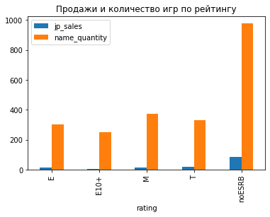

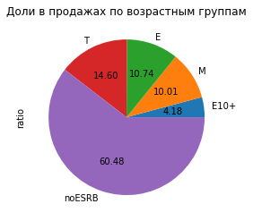

```python
display('Продаж в Японии и оценки ESRB в актуальный период')
# составим таблицу продаж и количества игр по рейтингу
jp_sales_rating_pivot = data.pivot_table(index=['rating'], values=['jp_sales'], aggfunc=['sum', 'count'])
# поменяем название столбцов
jp_sales_rating_pivot.columns = ['jp_sales', 'name_quantity']
# посчитаем доли продаж по возрастным группам
jp_sales_rating_pivot['ratio'] = jp_sales_rating_pivot['jp_sales'] / jp_total_sales
# выведем таблицу и графики
display (jp_sales_rating_pivot)
jp_sales_rating_pivot.plot( kind='bar'
                           , y= ['jp_sales', 'name_quantity']
                           , title = 'Продажи и количество игр по рейтингу'
)
plt.show
jp_sales_rating_pivot.sort_values(by='ratio').plot( kind='pie'
                                                   , autopct='%.2f'
                           , y= 'ratio'
                           , title = 'Доли в продажах по возрастным группам'
                           , legend=False
                                )
plt.show
```

### Другие регионы

#### ТОП-5 платформ по продажам в других регионах.

```python
# общий размер рынка
other_total_sales = platforms_all_sales['other_all_sales'].sum()
# определим доли по платформам
platforms_all_sales['other_market_share'] = platforms_all_sales['other_all_sales'] / other_total_sales
# выведем только запрошенную информацию
# platforms_all_sales.sort_values(by='other_all_sales', ascending=False, ignore_index=True)
(platforms_all_sales
 .sort_values(by='other_all_sales', ascending=False, ignore_index=True)[['platform', 'other_all_sales', 'other_market_share']]
 .head())
```

|  | platform | other_all_sales | other_market_share |
| --- | --- | --- | --- |
| 0 | PS4 | 48.35 | 0.402782 |
| 1 | PS3 | 26.77 | 0.223009 |
| 2 | XOne | 14.27 | 0.118877 |
| 3 | X360 | 12.11 | 0.100883 |
| 4 | 3DS | 6.28 | 0.052316 |

#### ТОП-5 жанров по продажам в других регионах

| genre | other_sales | market_share |
| --- | --- | --- |
| Action | 37.27 | 0.310480 |
| Shooter | 28.77 | 0.239670 |
| Sports | 19.45 | 0.162029 |
| Role-Playing | 11.48 | 0.095635 |
| Misc | 6.09 | 0.050733 |

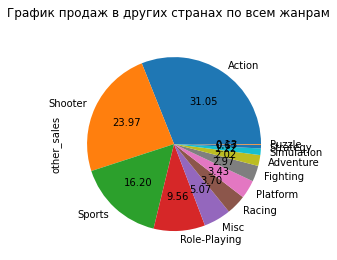

```python
# display('Продажи в других регионах по жанрам')
# делаем сводную таблицу по жанрам и продажам
genre_other_sales_sum_pivot_table = data.pivot_table(index='genre', values='other_sales', aggfunc='sum')\
                                        .sort_values(by='other_sales', ascending=False)
# вычисляем доли
genre_other_sales_sum_pivot_table['market_share'] = genre_other_sales_sum_pivot_table['other_sales'] / other_total_sales
display(genre_other_sales_sum_pivot_table.head())
genre_other_sales_sum_pivot_table.plot(kind='pie', y= 'other_sales', subplots=True
                                       , title='График продаж в других странах по всем жанрам'
                                       , autopct='%.2f'
                                       , legend=False)
plt.show()
```

#### ESRB рейтинг, возратные группы и продажи в других регионах

По информации сайта www.esrb.org эти категории можно соотнести со следующими возрастными группами (по годам), более привычными в России:

- E - 0+
- E10+ - 10+
- T - 13+
- M - 17+
- RP - рейтинг в ожидании. Иногда добавляется возрастная группа, к чему стремиться ожидание, например, 17+.
- A - 18+

Если мы согласимся с предположениями:

- взрослые (18+) платят за игры,
- взрослые покупают игры для детей, подростков и себе по возрастам,
- количество игр на каждого игрока одинаковое (**это спорное, но важное предположение**),

то продажи по рейтингам ESRB могут показать нам возрастные группы игроков (их доли) в соответствии с возрасными группами, описанными выше.

```
'Продаж в других регионах и оценки ESRB в актуальный период'
```

| rating | other_sales | name_quantity | ratio |
| --- | --- | --- | --- |
| E | 22.61 | 302 | 0.188354 |
| E10+ | 12.57 | 252 | 0.104715 |
| M | 47.11 | 372 | 0.392453 |
| T | 14.29 | 333 | 0.119044 |
| noESRB | 23.46 | 978 | 0.195435 |

```
<function matplotlib.pyplot.show(close=None, block=None)>
```

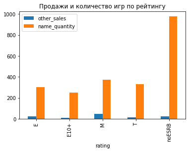

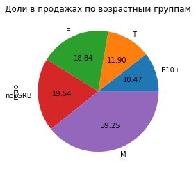

```python
display('Продаж в других регионах и оценки ESRB в актуальный период')
# составим таблицу продаж и количества игр по рейтингу
other_sales_rating_pivot = data.pivot_table(index=['rating'], values=['other_sales'], aggfunc=['sum', 'count'])
# поменяем название столбцов
other_sales_rating_pivot.columns = ['other_sales', 'name_quantity']
# посчитаем доли продаж по возрастным группам
other_sales_rating_pivot['ratio'] = other_sales_rating_pivot['other_sales'] / other_total_sales
# выведем таблицу и графики
display (other_sales_rating_pivot)
other_sales_rating_pivot.plot( kind='bar'
                           , y= ['other_sales', 'name_quantity']
                           , title = 'Продажи и количество игр по рейтингу'
)
plt.show
other_sales_rating_pivot.sort_values(by='ratio').plot( kind='pie'
                           , y= 'ratio'
                           , title = 'Доли в продажах по возрастным группам'
                                                    , autopct='%.2f'
                           , legend=False
)
plt.show
```

**Выводы для Других регионов:**

- Лидеры соотношения продаж и количества игры у рейтингов E(0+) и M(17+). Причем у М двухкратное приемущество.
- Ну и главный вывод категирии А почти нет. Все в М.
- Можно утверждать, что влияние ESRB в других регионах среднее.

#### Выводы о типовом пользователе из каждого региона

Возьмем информацию их первых строк:

- 1 или 2 платформы
- 3 жанра
- отношение к рейтингу ESRB

**Северо-американец**:

- PS4, XOne
- Action, Shooter, Sports
- рейтин ESRB важно

**Европеец**:

- PS4
- Action, Shooter, Sports
- рейтин ESRB важно

**Японец**:

- 3DS
- Role-Playing, Action, Misc
- рейтин ESRB не важен или имее отбратную силу, скорее всего существует японский рейтинг

**Другие регионы**:

- PS4
- Action, Shooter, Sports
- рейтин ESRB влияет средне.

Более побробно можно посмотреть в разделе выше для каждого региона.

## Проверка гипотиз

### Проверка гипотизы: Средние пользовательские рейтинги игр на платформах Xbox One и PC одинаковые

Так как в атуальном периоде данных не очень много, мы можем взглянуть на наши данные.

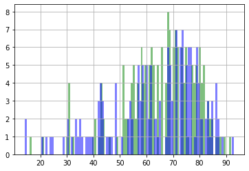

```python
data.loc[(data['platform'] == 'XOne') & (data['user_score'].notna()), 'user_score'].hist(bins=100, alpha=0.5, color='green')
data.loc[(data['platform'] == 'PC') & (data['user_score'].notna()), 'user_score'].hist(bins=100, alpha=0.5, color='blue')
```

Сформулируем нулевую гипотизу.

```
H_0: Средний пользовательский рейтинг игр (user_score) на платформе Xbox One (platform == XOne) =
        Средний пользовательский рейтинг игр (user_score) на платформе PC (platform == PC)
H_1: Средний пользовательский рейтинг игр (user_score) на платформе Xbox One (platform == XOne) ≠
        Средний пользовательский рейтинг игр (user_score) на платформе PC (platform == PC)
alpha = 0.05
```

При формулировании H_0 я стремился сделать утверждение содержащие знак равенства.

Так как по теории для экономии машинного ресурса мы не делаем расчеты по всей генеральной совокупности оценок пользоватей, например, для `XOne`, а по выборкам значений стараемся создать нормальное распределение вокруг значения стремящегося(близкого) к среднему всей генеральной совокупности. А после выборками из второй генеральной совокупности, например, для `PC`, смотрим насколько получемое в выборке среднее близко к среднему первой генеральной совокупности и на сколько эта выборка вероятна, если бы была из первой генеральной совокупности.

С учетом достаточной независимости выборок, я выбрал метод ttest_ind, который сделает эту работу для нас.

При этом по теории мы только отвергаем или не отвергаем гипотизы, уверенность нам дадут только результаты по генеральным совокупностям.

К счастью, наши генеральные совокупности достаточно малы, чтобы после проверок гипотиз узнать правду. Но не будем забывать, что наши данные это тоже выборка... Поэтому на небольшие различия можно будет закрыть глаза и улыбнуться.

H_1 - это отрицание H_0. Сейчас для нас не важны знаки больше и меньше.

Поменяем типы данных наших генеральных совокупностей и проверим их длины

```python
xone_notna_user_score = data.loc[(data['platform'] == 'XOne') & (data['user_score'].notna()), 'user_score'].astype('int')
# xone_notna_user_score.describe()
xone_notna_user_score.count()
```

```
182
```

```python
pc_notna_user_score = data.loc[(data['platform'] == 'PC') & (data['user_score'].notna()), 'user_score'].astype('int')
# pc_notna_user_score.describe()
pc_notna_user_score.count()
```

```
158
```

Так как длины не сильно различаются, то `equal_var` будет **True**. Это не единственная причина, дистперсия тоже важна.

Возмем alpha 0.05. Это даст уверенность, что среднее значение выборки будет достаточно вероятно и близко (в пределах "усов").

```python
results = st.ttest_ind(xone_notna_user_score, pc_notna_user_score, equal_var=True)

# alpha = задайте значение уровня значимости
alpha = 0.05

# вывод значения p-value на экран
display(results.pvalue)

# условный оператор с выводом строки с ответом
if results.pvalue < alpha:
    print ('Отвергаем нулевую гипотезу')
else:
    print ('Не получилось отвергнуть нулевую гипотезу')
```

```
0.15503167687396693
```

```
Не получилось отвергнуть нулевую гипотезу
```

**Вывод**: Скорее всего, **гипотиза**: Средние пользовательские рейтинги игр на платформах Xbox One и PC одинаковые - **верна**. Мы не смогли ее отвергнуть.

И обещанная проверка.

```python
display('Средний рейтинг пользователей для игр на Xbox One =', xone_notna_user_score.mean())
display('Средний рейтинг пользователей для игр на PC =', pc_notna_user_score.mean())
```

```
'Средний рейтинг пользователей для игр на Xbox One ='
```

```
65.21428571428571
```

```
'Средний рейтинг пользователей для игр на PC ='
```

```
62.80379746835443
```

Улыбнемся. ttest_ind работает.

### Проверка гипотизы: Средние пользовательские рейтинги игр жанров Action (англ. «действие», экшен-игры) и Sports (англ. «спортивные соревнования») разные.

Так как в атуальном периоде данных не очень много, мы можем взглянуть на наши данные.

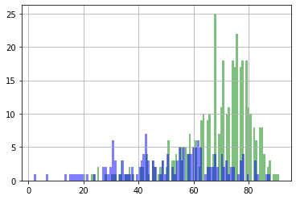

```python
data.loc[(data['genre'] == 'Action') & (data['user_score'].notna()), 'user_score'].hist(bins=100, alpha=0.5, color='green')
data.loc[(data['genre'] == 'Sports') & (data['user_score'].notna()), 'user_score'].hist(bins=100, alpha=0.5, color='blue')
```

Сформулируем нулевую гипотизу. Пойдем от обратного, если H0 мы сможем отвергнуть, то, скорее всего наша гипотиза верна.

```
H_0: Средний пользовательский рейтинг игр (user_score) жанра Action (genre == Action) =
        Средний пользовательский рейтинг игр (user_score) жанра Sports (genre == Sports)
H_1: Средний пользовательский рейтинг игр (user_score) жанра Action (genre == Action) ≠
        Средний пользовательский рейтинг игр (user_score) жанра Sports (genre == Sports)
alpha = 0.05
```

**При формулировании H_0 я стремился сделать утверждение содержащие знак равенства. Поэтому мы использовали метод от обратного.**

Так как по теории для экономии машинного ресурса мы не делаем расчеты по всей генеральной совокупности оценок пользоватей, например, для `XOne`, а по выборкам значений стараемся создать нормальное распределение вокруг значения стремящегося(близкого) к среднему всей генеральной совокупности. А после выборками из второй генеральной совокупности, например, для `PC`, смотрим насколько получемое в выборке среднее близко к среднему первой генеральной совокупности и на сколько эта выборка вероятна, если бы была из первой генеральной совокупности.

С учетом достаточной независимости выборок, я выбрал метод ttest_ind, который сделает эту работу для нас.

При этом по теории мы только отвергаем или не отвергаем гипотизы, уверенность нам дадут только результаты по генеральным совокупностям.

К счастью, наши генеральные совокупности достаточно малы, чтобы после проверок гипотиз узнать правду. Но не будем забывать, что наши данные это тоже выборка... Поэтому на небольшие различия можно будет закрыть глаза и улыбнуться.

H_1 - это отрицание H_0. Сейчас для нас не важны знаки больше и меньше.

И не будем забывать, что, если H_0 будет отвергнута, то наша проверяемая гипотеза скорее всего верна.

Проверим длины наших генеральных совокупностей.

```python
data.loc[(data['genre'] == 'Action') & (data['user_score'].notna()), 'user_score'].count()
```

```
392
```

```python
data.loc[(data['genre'] == 'Sports') & (data['user_score'].notna()), 'user_score'].count()
```

```
160
```

Дисперсия скорее равна, чем не равна. Так как длины различаются более чем в 2 раз для подстраховки `equal_var` будет **False**

Возмем alpha 0.05. Это даст уверенность, что среднее значение выборки будет достаточно вероятно и близко (в пределах "усов").

```python
# results = вызов метода для проверки гипотезы
results = st.ttest_ind(data.loc[(data['genre'] == 'Action') & (data['user_score'].notna()), 'user_score'].astype('int'),
                       data.loc[(data['genre'] == 'Sports') & (data['user_score'].notna()), 'user_score'].astype('int'),
                      equal_var=False)
# alpha = задайте значение уровня значимости
alpha = 0.05

# вывод значения p-value на экран
display(results.pvalue)

# условный оператор с выводом строки с ответом
if results.pvalue < alpha:
    print ('Отвергаем нулевую гипотезу')
else:
    print ('Не получилось отвергнуть нулевую гипотезу')
```

```
1.3883444596406352e-20
```

```
Отвергаем нулевую гипотезу
```

**Вывод**: Скорее всего, **гипотиза**: Средние пользовательские рейтинги игр жанров Action (англ. «действие», экшен-игры) и Sports (англ. «спортивные соревнования») разные - **верна**. Мы смогли отвергнуть обратную гипотизу.

И обещанная проверка.

```python
display('Средний рейтинг пользователей для жанра на Action ='
        , data.loc[(data['genre'] == 'Action') & (data['user_score'].notna()), 'user_score'].astype('int').mean())
display('Средний рейтинг пользователей для жанра Sports'
        , data.loc[(data['genre'] == 'Sports') & (data['user_score'].notna()), 'user_score'].astype('int').mean())
```

```
'Средний рейтинг пользователей для жанра на Action ='
```

```
68.375
```

```
'Средний рейтинг пользователей для жанра Sports'
```

```
52.38125
```

Различия большие. Улыбнемя. ttest_ind работает.

## Общий вывод

**Цели исследования**:

- Нужно выявить определяющие успешность игры закономерности. Это позволит сделать ставку на потенциально популярный продукт и спланировать рекламные кампании.
- Нужно отработать принцип работы с данными для прогнозирования кампаний на будущие года. Перед нами данные до 2016 года. Представим, что сейчас декабрь 2016 г., и мы планируем кампанию на 2017-й. (Неважно, прогнозируем ли мы продажи на 2017 год по данным 2016-го или же 2027-й — по данным 2026 года.)

Для достижения целей исследования мы сделали следующую работу:

- подготовили данные, заменили пропуски, где это возможно и нужно, проверили на неявные дубликаты,
- нашли срок, в который активно пишут игры для платформ- 7-8 лет в среднем,
- определили активный период для наших исследований: половину от 8 лет, то есть 4 года,
- актуализировали данные, платформы, жанры,
- составили портрет покупателя в различиных регионах,
- проверили 2 гипотизы,
- и подготовили кучу дополнительно статистики, например, какой рынок больше, ТОП-n игр для ТОП-m платформ...

Как же это поможет для достижения наших целей? То, что мы сделали - это первая часть ответа на второй поврос: **Нужно отработать принцип работы с данными для прогнозирования кампаний на будущие года.** А вторая часть, это та работа, которая сделана для ответа на первый вопрос: На основе актуальных данных за актуальных период находим актуальные ответы на следующий год (2017).

**Что определяет успешность игры в 2017 году?**

1. Игра должна быть написана для платформы из ТОП-5 (1, 2, 3) для региона, где вы планируете её продавать.
2. Не должно быть плохих отзывов критиков. В идиале оценки больше 70 из 100. Это для всех регионов, кроме Японии.
3. Для японского рынка не должно быть плохих отзывов пользователей, особенно для платформ Wii и WiiU.

По сумме информации:

- PS4 - перспективна, закупаемся на 7 из 10, смотрим отзывы критиков, можно брать новинки
- PS3 - поддерживаем ассортимент, закупаемся на 4 из 10, смотрим отзывы критиков
- XOne - перспективна, закупаемся на 10 из 10, смотрим отзывы критиков, нужно брать новинки
- 3DS - потенциально перспективно, закупаемся на 3 из 10, смотрим отзывы критиков
- X360 - поддерживаем ассортимен(старичек еще крепок), закупемся на 8 из 10, смотрим отзывы критиков
- WiiU - потенциально перспективно, закупаемся на 4 из 10, смотрим отзывы пользователей, можно брать новинки
- PC - поддерживаем ассортимент, закупаемся на 2 из 10 (Европа), смотрим отзывы критиков
4. Жанры **Action**, Shooter, Sports для всех кроме Японии.(в порядке убывания популярности)
5. Жанры для Японии Role-Playing, Action, Misc. (в порядке убывания популярности)
6. Жанры общий ТОП-5 по платформам: **Shooter, Sports, Platform, Role-Playing, (Racing, Fighting)**. На тот случай, если вы будете закупать игры, мало смотря на рейтинг каждой из них, например, для новых игр.
7. Для самых крупных рынков Североной Америки и Европы нужно, чтобы у игры был рейтинг ESRB. Если это М, то совсем хорошо.
8. Для Японии лучше приглядется к местным рейтингам. Там ESRB не любят.
9. И, конечно, не плохо свериться с ТОП-n игр для ТОП-m платформ в разделе 3.7...

Для 1-7 пунктов немного подробнее это можно посмотреть в 4 разделе.

**Чтобы "Стримчик" взлетел**, нужно:

- Понять долю рынка в каждом регионе.
- Понять размер рынка в каждом регионе.
- Закупиться играми по закономерностям, описанным выше, в количестве расчетанными по первым двум пунктам.
- А дальше ... вы и сами знаете...